# Satellite Validation Results

Interactive summary of sensor, correction, and processing comparisons for *in situ* measured variables from different sources, seasons, and sites for four French RiOMar

## Overview

This report explains the validation results of a comparison of **SEXTANT** and **ODATIS-MR expert** products against *in situ* data measured by the [REPHY](https://www.seanoe.org/data/00361/47248/) and [SOMLIT](https://www.somlit.fr/en/) networks. The coordinates for the sites named in the tables below may be found via the REPHY and SOMLIT databases. Each row compares a satellite product against in situ observations for a specific sensor, correction, processing chain, zone, source, site, season, measured *in situ* variable, and the corresponding satellite variable.

The data validated in this study were constrained to four of the French RiOMar, as seen below.

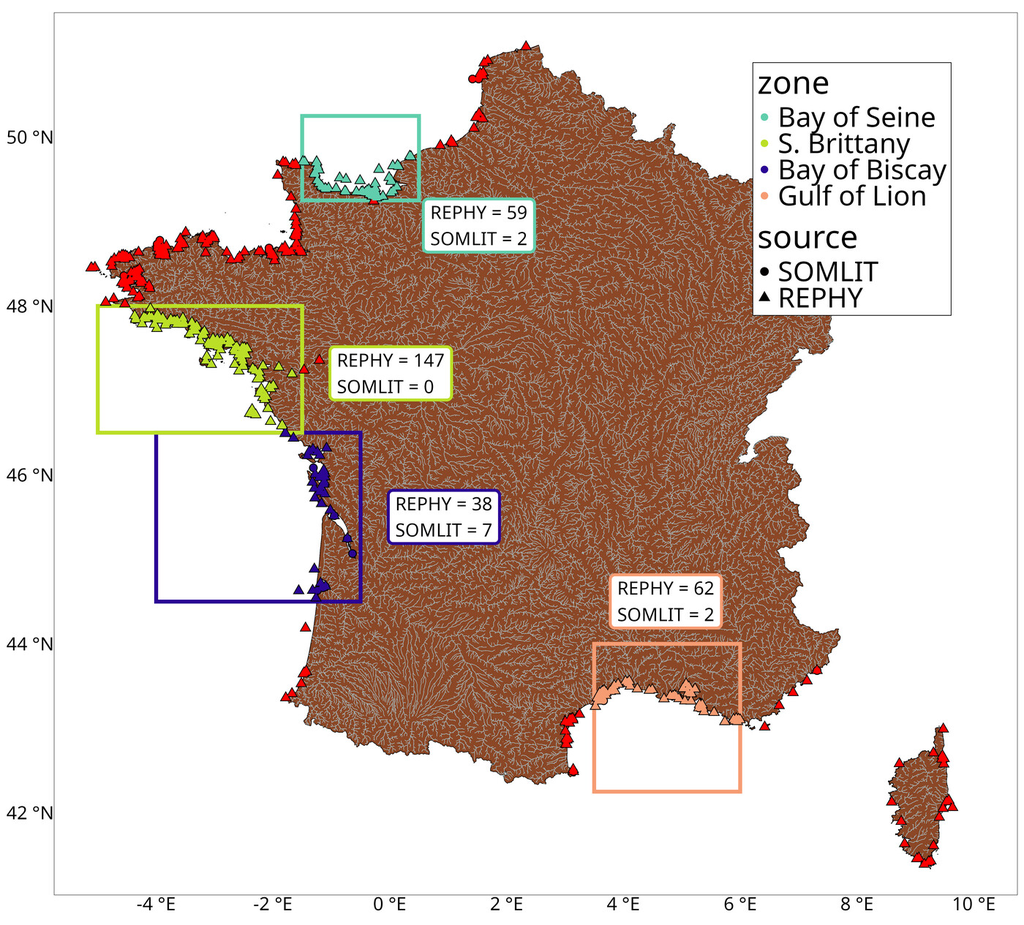

REPHY and SOMLIT stations validated in this report.

The data from these stations were filtered to the dates and times when overhead satellite passes were available. For daytime values the time window was 10:00 to 14:00, and for nighttime values (SST only) this window was 00:00 to 09:00. Note that while 09:00 is a bit late into the morning, there were very few early morning measurements available for comparison otherwise.

The satellites used here have two different resolutions. **SEXTANT** is ~1 km, while **ODATIS-MR** is ~300 m. Therefore, for the **SEXTANT** data a 3x3 grid of pixels was extracted around each station, and for **ODATIS-MR** this was 7x7. In this way roughly a 1 km ring was extracted around each *in situ* station for each matchup. Finally, the coefficient of variation (CV; standard deviation / mean; %) was computed across all extracted pixels and any days with a CV >20% were discarded. The resulting paired satellite and in situ observations were then compared using a variety of metrics, which are presented below.

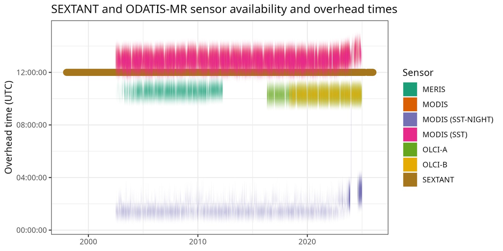

Time coverage across all sensors.

Satellite Sensors

5

In situ Sites

GLOBAL/ALL rows

46

Seasonal rows

2,286

Site-specific rows

5,349

All result rows

8,258

The rows and charts below are colour coded by the *in situ* variable used for the comparison:

CHLASPMTEMPTUR

These are chlorophyll (CHLA), suspended particulate matter (SPM), temperature (TEMP), and turbidity (TUR), respectively.

## How to Read the Results

| Metric | Interpretation |
| --- | --- |
| `n` | Number of paired satellite and in situ observations. |
| `Bias` | Mean signed difference. Positive or negative values show systematic over- or under-estimation. |
| `Error` | Mean unsigned percentage error. |
| `Slope` | Linear slope between satellite and in situ values. Values near 1 indicate proportional agreement. |
| `Slope_log` | Slope after log transformation of the data. Ideal for non-temperature data. |

## Scatterplots

Scatterplots for the GLOBAL results are available for every matchup shown in the summary dashboard below. These may be accessed via the GitHub interface directly within this [folder](https://github.com/RiOMar-projet/sat_access/tree/main/validation/scatterplot).

## Summary Dashboard

Sensors are compared on the x-axis; bars are coloured by variable. Each distinct correction / processing combination produces its own dodged bar, labelled above. Use the four filter boxes to select which sensors, corrections, processing chains, and variables to include; the **Bias / Error / Slope** buttons switch the metric shown. Click a variable in the legend to show or hide it.

Variable

Sensor

Correction

Processing

[interactive chart not shown]

### Seasonal Summary

Distribution of Bias values by season (`site = ALL`). Linked to the dashboard filters above: selecting a sensor, correction, or processing combination updates this chart to show only matching matchups.

[interactive chart not shown]

## Explore by Metric

Pick a metric and a grouping variable to explore the same GLOBAL/ALL summary rows from a different angle.

[interactive chart not shown]

## Results Table

All 8,258 validation rows. The first three columns (sensor, corr., proc.) are pinned and remain visible while scrolling right — “corr.” and “proc.” are abbreviations for correction and processing. Categorical columns show tick-boxes; select any combination to filter by multiple values simultaneously. Metric columns (n, Bias, Error, Slope, Slope_log) show Min / Max numeric entry boxes; the site column accepts free text. Click any header to sort. The CSV button exports the currently filtered rows; the Excel button downloads the full dataset. Rows with empty metric values indicate that too few matchups existed for that sensor / site / season combination to compute reliable statistics. Rows are coloured by `variable`: CHLA SPM TEMP TUR.

Excel (all rows)

| sensor | corr. | proc. | zone | source | site | season | variable | var (sat) | n | Bias | Error | Slope | Slope_log |
| --- | --- | --- | --- | --- | --- | --- | --- | --- | --- | --- | --- | --- | --- |
| MERIS | AC | OC5 | GLOBAL | ALL | ALL | ALL | CHLA | CHL | 183 | 27.71 | 76.58 | 0.8 | 0.56 |
| MERIS | PO | OC5 | GLOBAL | ALL | ALL | ALL | CHLA | CHL | 663 | 54.18 | 78.63 | 0.49 | 0.52 |
| MERIS | AC | NA | GLOBAL | ALL | ALL | ALL | CHLA | CHL1 | 232 | 131.44 | 164.06 | 0.67 | 0.47 |
| MERIS | PO | NA | GLOBAL | ALL | ALL | ALL | CHLA | CHL1 | 754 | 22.56 | 86.35 | -0.02 | 0.32 |
| MERIS | PO | FNU | GLOBAL | ALL | ALL | ALL | TUR | T | 253 | -73.78 | 77.7 | 0.31 | 0.73 |
| MERIS | AC | FNU | GLOBAL | ALL | ALL | ALL | TUR | T | 48 | -17.51 | 59.92 | 0.53 | 0.57 |
| MERIS | AC | GONS | GLOBAL | ALL | ALL | ALL | CHLA | CHL | 11 | 56.61 | 73.51 | 0.4 | 0.36 |
| MERIS | PO | GONS | GLOBAL | ALL | ALL | ALL | CHLA | CHL | 6 | 28.41 | 124.8 | 0.29 | 0 |
| MERIS | PO | G | GLOBAL | ALL | ALL | ALL | SPM | SPM | 29 | -128.1 | 163.65 | 0.11 | 0.62 |
| MERIS | PO | R | GLOBAL | ALL | ALL | ALL | SPM | SPM | 41 | -44.48 | 96.3 | 0.21 | 0.64 |

[output cut: 8248 more lines]